# 1. Data exploration

### Kατανομή των ημερήσιων λογαριθμικών αποδόσεων και την κατανομή της ενδοημερήσιας μεταβλητότητας

Αυτό το βήμα δημιουργεί για κάθε asset δύο διαγράμματα πυκνότητας κατανομής (histograms) με στόχο τη μελέτη της συμπεριφοράς των αποδόσεων και της μεταβλητότητας:

- Υπολογίζεται η ενδοημερήσια μεταβλητότητα ως διαφορά μεταξύ της υψηλότερης και της χαμηλότερης τιμής της ημέρας:

  ```
  df['Volatility'] = df['High'] - df['Low']
  ```

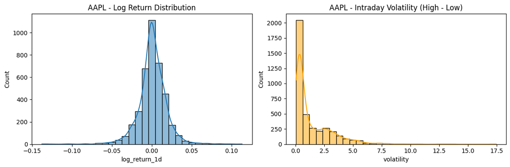

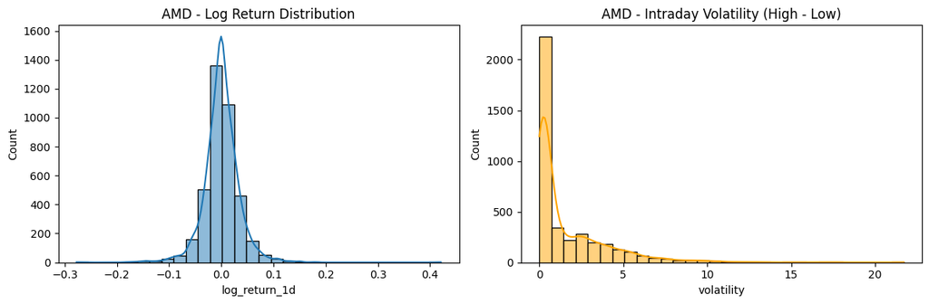

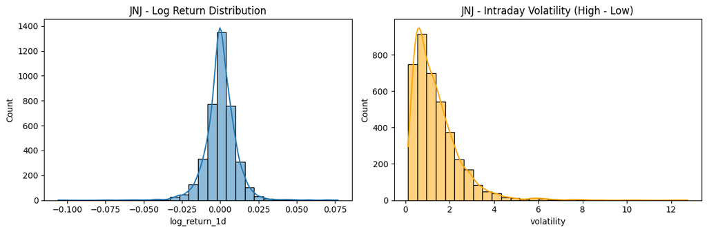

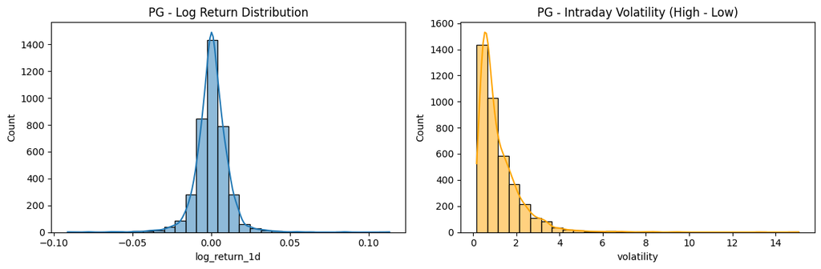

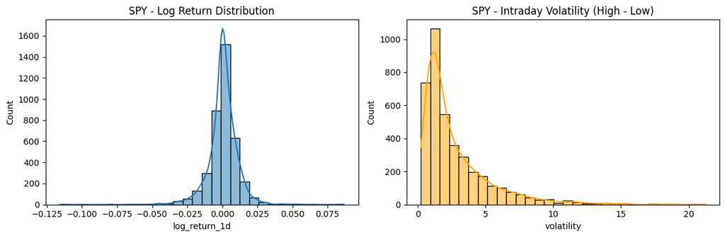

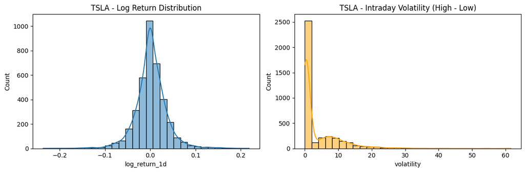

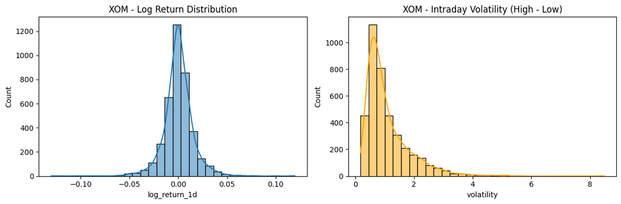

```python
for ticker, df in full_datasets.items():
    df["volatility"] = df["high"] - df["low"]
    plt.figure(figsize=(12, 4))
    plt.subplot(1, 2, 1)
    sns.histplot(df["log_return_1d"].dropna(), bins=30, kde=True)
    plt.title(f"{ticker} - Log Return Distribution")
    plt.subplot(1, 2, 2)
    sns.histplot(df["volatility"].dropna(), bins=30, kde=True, color='orange')
    plt.title(f"{ticker} - Intraday Volatility (High - Low)")
    plt.tight_layout()
    plt.savefig(f'./exploration/{ticker}_log_return.png', dpi=300, bbox_inches='tight')
    plt.show()
```

### Υπολογισμός Sharpe Ratio και Kινούμενων στατιστικών

#### Kινούμενες στατιστικές :

- Υπολογίζεται η **κινητή μέση απόδοση 21 ημερών** (`rolling_return_21d`) και η **κινητή τυπική απόκλιση** (`rolling_volatility_21d`) με χρήση παραθύρου 21 ημερών.
- Δημιουργείται διάγραμμα γραμμής για την 21-ημερη απόδοση και την 21-ημερη μεταβλητότητα στο ίδιο plot.

#### Sharpe Ratio:

- Για κάθε τιψκερ υπολογίζεται το **Sharpe Ratio** με βάση τις ημερήσιες λογαριθμικές αποδόσεις και δείχνονται σε διάγραμμα barplot.

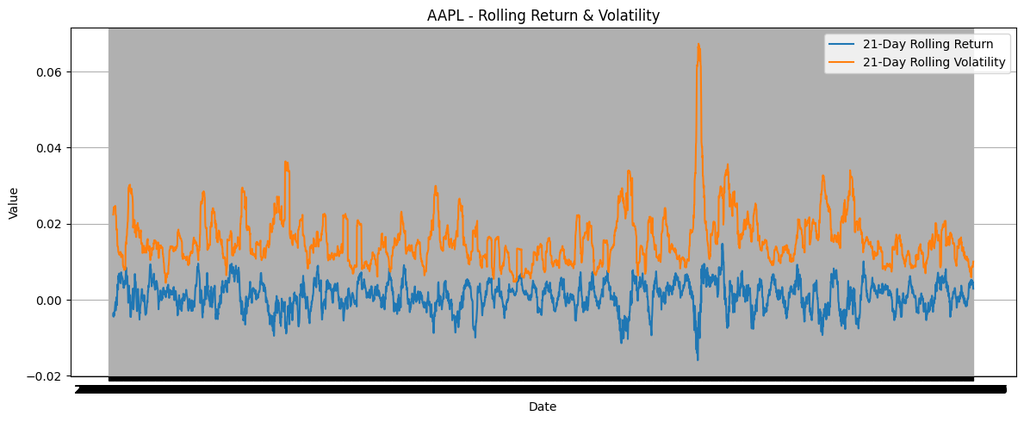

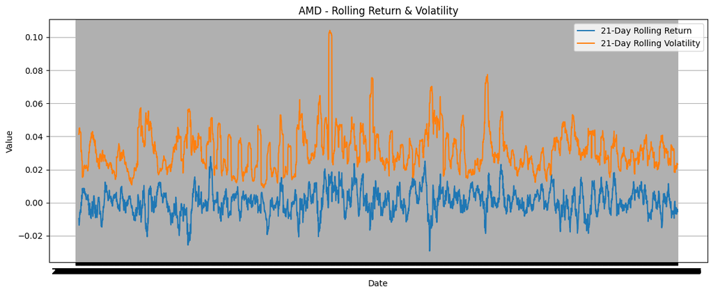

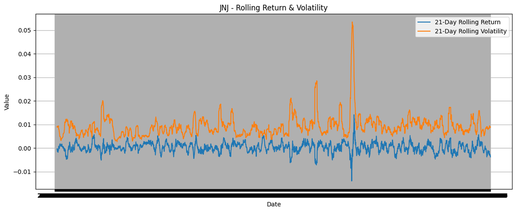

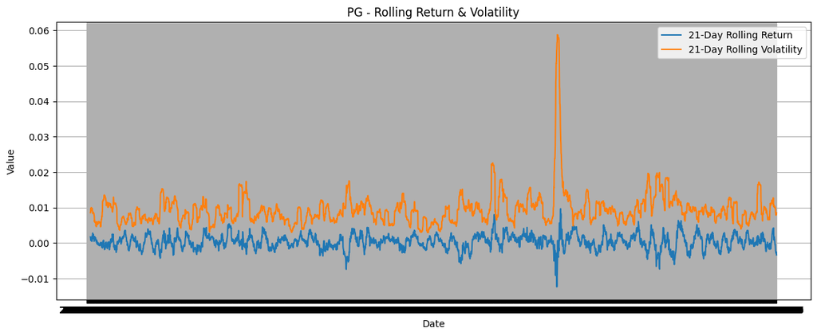

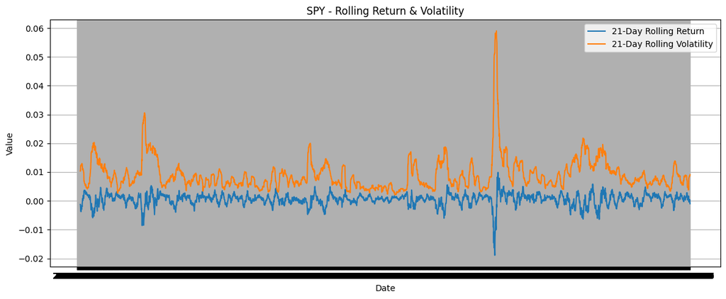

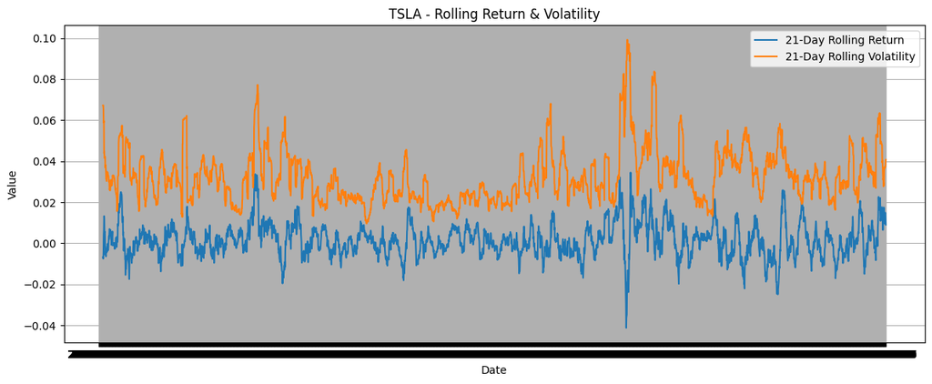

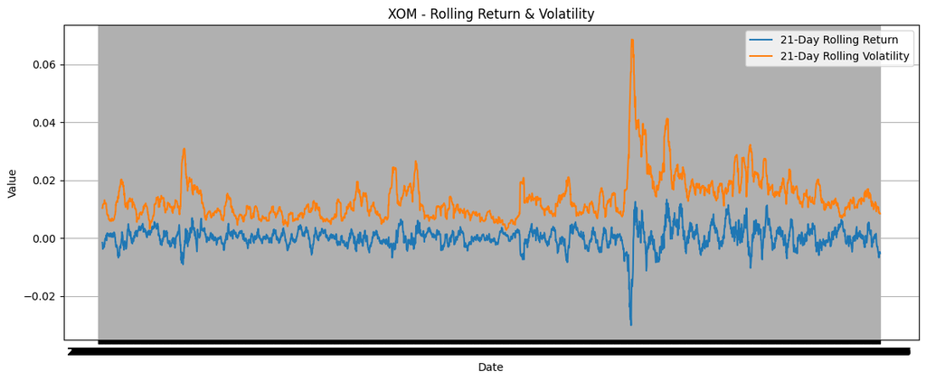

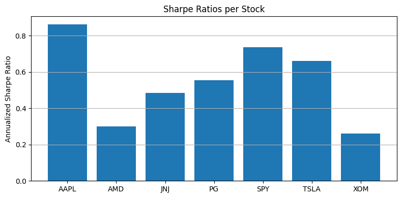

```python
sharpe_ratios = {}

for name, df in full_datasets.items():
    df["rolling_return_21d"] = df["log_return_1d"].rolling(window=21).mean()
    df["rolling_volatility_21d"] = df["log_return_1d"].rolling(window=21).std()

    plt.figure(figsize=(12, 5))
    plt.plot(df["date"], df["rolling_return_21d"], label="21-Day Rolling Return")
    plt.plot(df["date"], df["rolling_volatility_21d"], label="21-Day Rolling Volatility")
    plt.title(f"{name} - Rolling Return & Volatility")
    plt.xlabel("Date")
    plt.ylabel("Value")
    plt.legend()
    plt.grid(True)
    plt.tight_layout()
    plt.savefig(f'./exploration/{name}_rolling.png', dpi=300, bbox_inches='tight')
    plt.show()

    returns = df["log_return_1d"].dropna()
    if len(returns) > 0 and returns.std() > 0:
        sharpe = returns.mean() / returns.std() * np.sqrt(252)
        sharpe_ratios[name] = sharpe

if sharpe_ratios:
    plt.figure(figsize=(8, 4))
    plt.bar(sharpe_ratios.keys(), sharpe_ratios.values())
    plt.ylabel("Annualized Sharpe Ratio")
    plt.title("Sharpe Ratios per Stock")
    plt.grid(True, axis='y')
    plt.tight_layout()
    plt.savefig(f'./exploration/sharpe_ratio.png', dpi=300, bbox_inches='tight')
    plt.show()
```